# **secr** simulations

Murray Efford

2025-08-28

# Effect of individual heterogeneity in detection parameters $\lambda_0$ and $\sigma$ on trend estimates MhT

The simulations described here are part of a series documenting the effect of breaching assumptions of spatially explicit capture–recapture models.

Variation among individuals in the probability of detection is a known cause of bias in many domains of capture–recapture. However, trend estimates are fairly robust (see Hines and Nichols 2002 for non-spatial scenarios, but “These approximations indicate that trap response is an especially important assumption violation that can produce substantial bias”.)

## Problem description

The SECR null model assumes $\lambda_0$ and $\sigma$ are the same across individuals. We generate populations with a multi-session trend in density sampled with heterogeneous $\lambda_0$ and $\sigma$, and examine estimates of density and trend (finite population growth rate $\lambda$) from a null model.

## Settings

Square grid of 64 binary proximity detectors at spacing $c = 2\sigma$.

The same conditions were used for simulation and fitting.

| Parameter | Value(s) |
| --- | --- |
| detectfn | ‘HHN’ |
| D | $0.5 \sigma^{-2}$ |
| mean lambda0 | 0.1 |
| mean sigma | c/2 |
| noccasions | 5 |
| nsessions | 5 |
| buffer | $4\sigma$ |
| nx | 32 |

## Package version, date and platform

```r
source('../setup.R')
runsim  <- FALSE
runsim2 <- FALSE
figures <- TRUE
cache   <- FALSE
nrepl   <- 200
nrepl2  <- 25
metadata(runsim, runsim2) # if runsim FALSE picks up saved metadata.RDS
```

```
## R version 4.3.2 (2023-10-31)
## Platform   x86_64-pc-linux-gnu (64-bit)
## Running    Rocky Linux 9.4 (Blue Onyx)
## secr       5.3.0 2025-08-10
## secrdesign 2.10.1 2025-08-10
## Threads    60
## nrepl      200
## Run        Thu Aug 14 11:49:11 2025
```

Note: ‘grdevice’ is set in setup.R to ‘ragg_png’ allowing graphics on NeSI.

Spatial units changed 2025-08-14: sigma = 1 m, D = 5000/ha

Note: could compare to PLB $\hat \lambda$ by setting renumber = FALSE in sim.capthist.

## Simulation code

### Define MhT scenarios

This function draws unique levels of the detection parameter lambda0 from a log-normal distribution for each member of a simulated population when used as the ‘covariates’ argument of `sim.popn`.

```r
popn.covariates <- function (animals, ...) {
    arg <- list(...)
    CVl <- if (is.null(arg$CVlambda0)) 0 else arg$CVlambda0
    mnl <- arg$lambda0
    mns <- arg$sigma
    n <- nrow(animals)
    data.frame(lambda0 = secr::rlnormCV(n, mnl, CVl), sigma = rep(mns,n))
}
```

The population arguments passed to run.scenarios include the mean and CV of each detection parameter.

```r
grid <- make.grid(nx = 8, ny = 8, spacing = 2, detector = "proximity")
poparg <- c(
    expand.arg(
        covariates = "popn.covariates",
        lambda0    = 0.1,
        sigma      = 1,
        CVlambda0  = seq(0,0.8,0.2),
        nsessions = 5,
        details   = list (lambda = 0.9)),
    expand.arg(
        covariates = "popn.covariates",
        lambda0    = 0.1,
        sigma      = 1,
        CVlambda0  = seq(0,0.8,0.2),
        nsessions = 5,
        details   = list (lambda = 1.1)))

detarg <- list(detectpar = list(individual = TRUE), renumber = FALSE)
trueD <- 5000  # per ha
scen <- make.scenarios(
    D          = trueD,
    noccasions = 5,
    detectfn   = 14,
    lambda0    = 0.1,
    sigma      = 1,        # m
    popindex   = 1:length(poparg),
    fitindex   = 1)
```

```r
scenarioSummary(scen, grid)
```

```
##    scenario trapsindex noccasions nrepeats    D lambda0 sigma detectfn     En    Er     Em   En2
## 1         1          1          5        1 5000     0.1     1       14 72.661 25.41 16.311 14.92
## 2         2          1          5        1 5000     0.1     1       14 72.661 25.41 16.311 14.92
## 3         3          1          5        1 5000     0.1     1       14 72.661 25.41 16.311 14.92
## 4         4          1          5        1 5000     0.1     1       14 72.661 25.41 16.311 14.92
## 5         5          1          5        1 5000     0.1     1       14 72.661 25.41 16.311 14.92
## 6         6          1          5        1 5000     0.1     1       14 72.661 25.41 16.311 14.92
## 7         7          1          5        1 5000     0.1     1       14 72.661 25.41 16.311 14.92
## 8         8          1          5        1 5000     0.1     1       14 72.661 25.41 16.311 14.92
## 9         9          1          5        1 5000     0.1     1       14 72.661 25.41 16.311 14.92
## 10       10          1          5        1 5000     0.1     1       14 72.661 25.41 16.311 14.92
##         esa CF rotRSE rotRSEB arrayN arrayspace arrayspan saturation detperHR.median       k
## 1  0.014532  1 0.1984  0.1874     64          2    19.799    0.26959               4 0.70711
## 2  0.014532  1 0.1984  0.1874     64          2    19.799    0.26959               4 0.70711
## 3  0.014532  1 0.1984  0.1874     64          2    19.799    0.26959               4 0.70711
## 4  0.014532  1 0.1984  0.1874     64          2    19.799    0.26959               4 0.70711
## 5  0.014532  1 0.1984  0.1874     64          2    19.799    0.26959               4 0.70711
## 6  0.014532  1 0.1984  0.1874     64          2    19.799    0.26959               4 0.70711
## 7  0.014532  1 0.1984  0.1874     64          2    19.799    0.26959               4 0.70711
## 8  0.014532  1 0.1984  0.1874     64          2    19.799    0.26959               4 0.70711
## 9  0.014532  1 0.1984  0.1874     64          2    19.799    0.26959               4 0.70711
## 10 0.014532  1 0.1984  0.1874     64          2    19.799    0.26959               4 0.70711
```

### Run MhT simulations

```r
fitarg <- list(detectfn = 'HHN', model = lambda0 ~ 1, details = list(Dlambda = TRUE))
MhTsims <- run.scenarios(
    nrepl     = nrepl,
    scenarios = scen,
    trapset   = grid,
    fit       = TRUE,
    pop.args  = poparg,
    det.args  = detarg,
    fit.args  = fitarg,
    seed      = 12345,
    xsigma    = 4,
    nx        = 32,
    extractfn = predictDlambda)

saveRDS(MhTsims, file = 'MhTsims.RDS')
```

```r
fitarg <- list(detectfn = 'HHN', model = list(D~1, lambda0 ~ 1), CL = TRUE, details = list(Dlambda = TRUE))
MhTCLsims <- run.scenarios(
    nrepl     = nrepl,
    scenarios = scen,
    trapset   = grid,
    fit       = TRUE,
    pop.args  = poparg,
    det.args  = detarg,
    fit.args  = fitarg,
    seed      = 12345,
    xsigma    = 4,
    nx        = 32,
    extractfn = predictDlambda)

saveRDS(MhTCLsims, file = 'MhTCLsims.RDS')
```

```r
exfn2 <- function (object) {
    pred <- predict(object)
    do.call(rbind, lapply(pred, '[',1,))
}
fitarg2 <- list(detectfn = 'HHN', type='PLBsecrl', model = lambda~1)
PLBsims <- run.scenarios(
    nrepl     = nrepl2,
    scenarios = scen,
    trapset   = grid,
    fit       = TRUE,
    fit.function = "openCR.fit",
    pop.args  = poparg,
    det.args  = detarg,
    fit.args  = fitarg2,
    seed      = 12345,
    xsigma    = 4,
    nx        = 32,
    extractfn = exfn2)
saveRDS(PLBsims, file = 'PLBsims.RDS')
```

MhTsims completed with 200 replicates on 60 threads in 961.4 minutes. MhTCLsims completed with 200 replicates on 60 threads in 567.5 minutes. PLBsims completed with 25 replicates on 60 threads in 1026.9 minutes.

## Results

```r
options(width=110, digits=4)
MhTsims <- readRDS(file = 'MhTsims.RDS')
onesim <- function (sim, parm = 'D1', fn = mean, field = 'estimate') {
    fn(sapply(sim, '[', parm,field))
}
mn <- function(x) mean(x, na.rm = TRUE)
se <- function(x) sd(x)/sqrt(sum(!is.na(x)))
nv <- function(x) sum(!is.na(x))
df <- data.frame(
    CVlambda0 = rep(seq(0,0.8,0.2),2),
    lambda    = rep(c(0.9,1.1), each = 5),
    nvalid    = sapply(MhTsims$output, onesim, 'D1', fn=nv),
    RBD       = sapply(MhTsims$output, onesim, 'D1', fn=mn) / trueD - 1,
    seRBD     = sapply(MhTsims$output, onesim, 'D1', fn=se) / trueD,
    lambda    = sapply(MhTsims$output, onesim, 'lambda1'),
    selambda  = sapply(MhTsims$output, onesim, 'lambda1', fn=se),
    SEestlam  = sapply(MhTsims$output, onesim, 'lambda1', fn=mn, field = 'SE.estimate')
)
df
```

```
##    CVlambda0 lambda nvalid       RBD    seRBD lambda.1 selambda SEestlam
## 1        0.0    0.9    200  0.008443 0.008824   0.9025 0.002690  0.03737
## 2        0.2    0.9    200 -0.023766 0.009180   0.9007 0.002830  0.03745
## 3        0.4    0.9    200 -0.103230 0.007558   0.9025 0.002748  0.03809
## 4        0.6    0.9    200 -0.184534 0.007413   0.9011 0.002605  0.03872
## 5        0.8    0.9    200 -0.270015 0.005981   0.8957 0.002925  0.03959
## 6        0.0    1.1    200  0.008313 0.008301   1.1001 0.002745  0.03729
## 7        0.2    1.1    200 -0.029472 0.008215   1.1004 0.003024  0.03756
## 8        0.4    1.1    200 -0.094439 0.007828   1.0975 0.002888  0.03783
## 9        0.6    1.1    200 -0.181581 0.006774   1.0996 0.002582  0.03856
## 10       0.8    1.1    200 -0.267342 0.006509   1.0995 0.002876  0.03944
```

Also tabulate conditional fits:

```r
options(width=110, digits=4)
MhTCLsims <- readRDS(file = 'MhTCLsims.RDS')
onesim <- function (sim, parm = 'D1', fn = mean, field = 'estimate') {
    fn(sapply(sim, '[', parm,field))
}
mn <- function(x) mean(x, na.rm = TRUE)
se <- function(x) sd(x)/sqrt(sum(!is.na(x)))
nv <- function(x) sum(!is.na(x))
dfCL <- data.frame(
    CVlambda0 = rep(seq(0,0.8,0.2),2),
    lambda    = rep(c(0.9,1.1), each = 5),
    nvalid    = sapply(MhTCLsims$output, onesim, 'lambda1', fn=nv),
    lambda    = sapply(MhTCLsims$output, onesim, 'lambda1', fn=mn),
    selambda  = sapply(MhTCLsims$output, onesim, 'lambda1', fn=se),
    SEestlam  = sapply(MhTCLsims$output, onesim, 'lambda1', fn=mn, field = 'SE.estimate')
)
dfCL
```

```
##    CVlambda0 lambda nvalid lambda.1 selambda SEestlam
## 1        0.0    0.9    200   0.8956 0.002707  0.03733
## 2        0.2    0.9    200   0.8950 0.002803  0.03738
## 3        0.4    0.9    200   0.8999 0.002961  0.03803
## 4        0.6    0.9    200   0.9007 0.002845  0.03864
## 5        0.8    0.9    200   0.8974 0.002647  0.03963
## 6        0.0    1.1    200   1.1009 0.002916  0.03724
## 7        0.2    1.1    200   1.1035 0.002787  0.03749
## 8        0.4    1.1    200   1.0985 0.002717  0.03810
## 9        0.6    1.1    200   1.0996 0.002857  0.03885
## 10       0.8    1.1    200   1.0990 0.002853  0.03945
```

```r
PLBsims <- readRDS(file = 'PLBsims.RDS')
dfPLB <- data.frame(
    CVlambda0 = rep(seq(0,0.8,0.2),2),
    truelambda = rep(c(0.9,1.1), each = 5),
    lambda = sapply(PLBsims$output, onesim, 'lambda'),
    selambda = sapply(PLBsims$output, onesim, 'lambda', fn=se),
    SEestlam  = sapply(PLBsims$output, onesim, 'lambda', fn=mn, field = 'SE.estimate')
)
dfPLB
```

```
##    CVlambda0 truelambda lambda selambda SEestlam
## 1        0.0        0.9 0.8964 0.007405  0.03393
## 2        0.2        0.9 0.9050 0.007592  0.03497
## 3        0.4        0.9 0.8955 0.008008  0.03480
## 4        0.6        0.9 0.9019 0.006909  0.03644
## 5        0.8        0.9 0.8921 0.007508  0.03672
## 6        0.0        1.1 1.1007 0.006378  0.03559
## 7        0.2        1.1 1.1091 0.008215  0.03588
## 8        0.4        1.1 1.0914 0.007515  0.03577
## 9        0.6        1.1 1.1058 0.006845  0.03718
## 10       0.8        1.1 1.0878 0.007597  0.03695
```

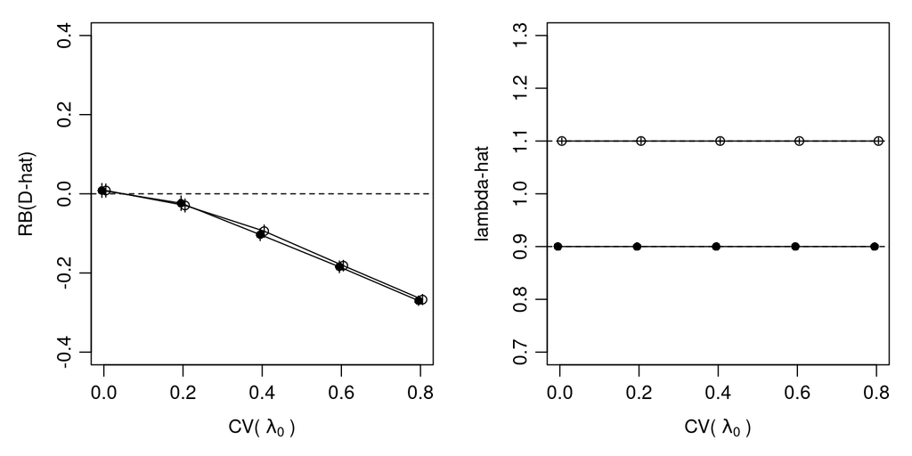

Relative bias of density and lambda estimates from null 5-session model given individual variation in lambda0

```r
cvltext <- expression(paste("CV( ", lambda[0], " )"))
x <- seq(0,0.8,0.20)
offset <- 0.005
par(mfrow = c(1,2), mar = c(4,4,1,1), mgp = c(2.4,0.7,0), bty = 'o')

plot(0,0, type = 'n', xlim = c(0,0.8), ylim = c(-0.4,0.4), xlab = cvltext, ylab = 'RB(D-hat)')
abline(h = 0, lty = 2)
addRB(x-offset, df[1:5,], mean = 'RBD', se = 'seRBD', type = 'o', pch = 16)
addRB(x+offset, df[6:10,], mean = 'RBD', se = 'seRBD', type = 'o', pch = 1)

plot(0,0, type = 'n', xlim = c(0,0.8), ylim = c(0.7,1.3), xlab = cvltext, ylab = 'lambda-hat')
abline(h = 0.9, lty = 2)
abline(h = 1.1, lty = 2)
addRB(x-offset, df[1:5,], mean = 'lambda', se = 'selambda', type = 'o', pch = 16)
addRB(x+offset, df[6:10,], mean = 'lambda', se = 'selambda', type = 'o', pch = 1)
```

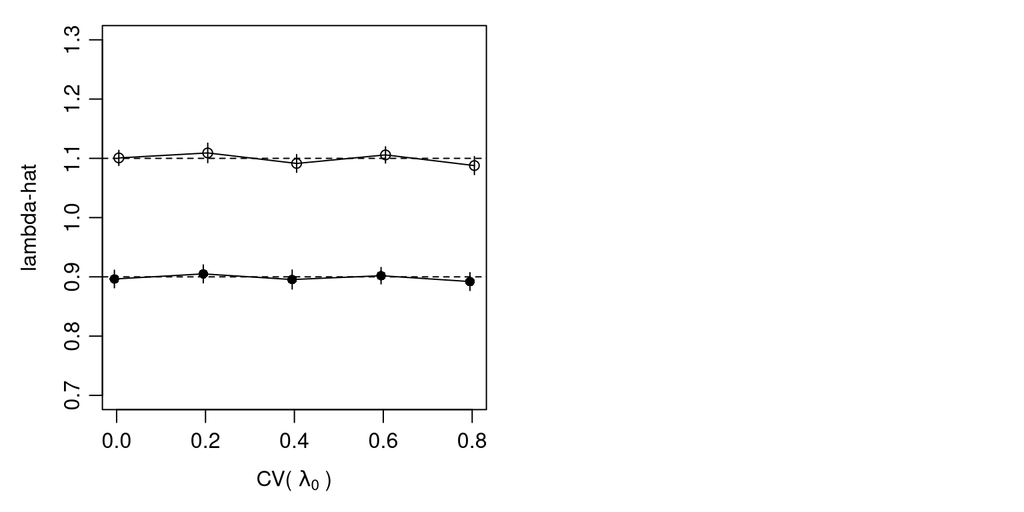

Relative bias of lambda-hat from null PLB open model given individual variation

```r
cvltext <- expression(paste("CV( ", lambda[0], " )"))
x <- seq(0,0.8,0.20)
offset <- 0.005
par(mfrow = c(1,2), mar = c(4,4,1,1), mgp = c(2.4,0.7,0), bty = 'o')

plot(0,0, type = 'n', xlim = c(0,0.8), ylim = c(0.7,1.3), xlab = cvltext, ylab = 'lambda-hat')
abline(h = 0.9, lty = 2)
abline(h = 1.1, lty = 2)
addRB(x-offset, dfPLB[1:5,], mean = 'lambda', se = 'selambda', type = 'o', pch = 16)
addRB(x+offset, dfPLB[6:10,], mean = 'lambda', se = 'selambda', type = 'o', pch = 1)
```

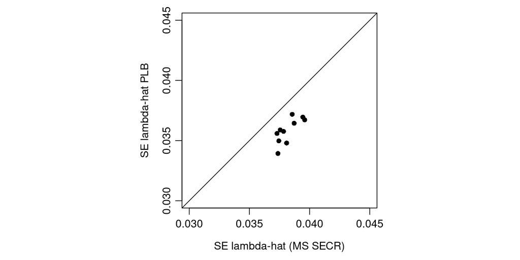

Estimated precision of lambda-hat from multisession SECR and PLB models

```r
par(mfrow = c(1,1), mar = c(4,4,1,1), mgp = c(2.4,0.7,0), bty = 'o', pty = 's')
plot(0,0, type = 'n', xlim = c(0.03,0.045), ylim = c(0.03,0.045),
     xlab = 'SE lambda-hat (MS SECR)', ylab = 'SE lambda-hat PLB')
points(df[1:10,'SEestlam'], dfPLB[1:10,'SEestlam'], type = 'p', pch = 16)
abline(0,1)
```

```r
mean(df[1:10,'SEestlam'] / dfPLB[1:10,'SEestlam'])
```

```
## [1] 1.066
```

## Interpretation

Estimates of density from the null model are moderately sensitive to individual variation in $\lambda_0$, but estimates of population trend $\lambda$ are unbiased.

## References

Hines, J. E. and Nichols, J. D. 2002. Investigations of potential bias in the estimation of $\lambda$ using Pradel’s (1996) model for capture–recapture data. Journal of Applied Statistics 29: 573–587.

Nichols, J. D. and Hines, J. E. 2002. Approaches for the direct estimation of $\lambda$, and demographic contributions to $\lambda$, using capture–recapture data, Journal of Applied Statistics 29: 539–568.